# Brownlows Bets

Briggette Adams

Nov. 16, 2019

### 0.0.1 2019-11-16

# 1 Introduction

At the first day of class there are 35 students in Math Statistics class and professor Brownlow always proposes this bet to his students “I will wager $2 to your bet of $1 that at least two people in today’s class have the same birthday. He tells me he has made that bet 1137 times so far. Where do you think his profits are? Discuss this in a markdown document

# 2 Methods

To estimate professor Brownlow’s earnings or losses after 1137 bets, the data sample gathered from the bets will be compiled by first setting a new object for birthdays (BDAYS) which will contain each possible day of the year from an interval 1:365. Then using our (BDAYS) object we will compare the sample tests of each bet results to whether or not they obtained a unique sample number < 35 which is the total number of birthdays per bet. After all 1,137 bets there will be a total amount of money for the bets either in positive or negative money total due to earnings or loses. This data will be shown as a 95% confidence interval over a histogram.

# 3 Profit Estimate

```r
Bdays = 1:365
Bsamples = vector("numeric")
TotalDollars = 0
SaveDollars = vector("numeric")
```

I am going to run the simulator 1137 times.

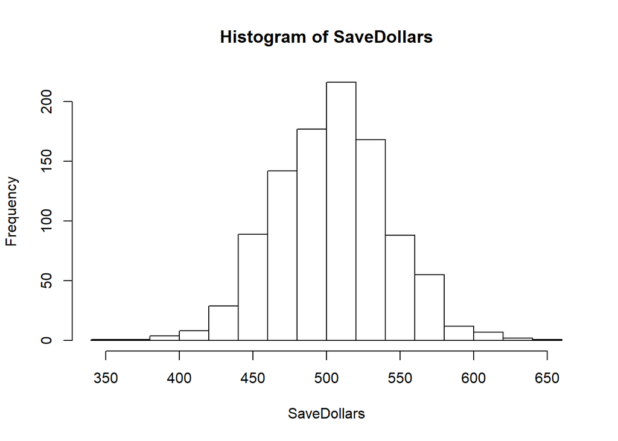

```r
for (loop in 1:1000) {

  TotalDollars = 0
  classsize = 35
  for (i in 1:1137) {
    Bsamples = sample(Bdays,35, replace = TRUE)
    if (length(unique(Bsamples)) == 35) {
      TotalDollars = TotalDollars -2
    } else{
      TotalDollars = TotalDollars +1
    }
  }

  SaveDollars[loop] = TotalDollars
}

hist(SaveDollars)
```

```r
var(SaveDollars)
```

```
## [1] 1519.33
```

```r
print(paste("average return =",mean(SaveDollars)))
```

```
## [1] "average return = 504.459"
```

# 4 Confidence interval of Brownlows earning

```r
varSorted = sort(SaveDollars)
LCL = varSorted[25]
UCL = varSorted[975]
print(paste("UCL = ",UCL, "LCL = ",LCL))
```

```
## [1] "UCL =  576 LCL =  429"
```

```r
stdevDollars = sd(SaveDollars)
meanDollars = mean(SaveDollars)
CI = c(meanDollars-2*stdevDollars, meanDollars+2*stdevDollars)

print(CI)
```

```
## [1] 426.5018 582.4162
```

The UCL is 576 and our LCL is 429 for this test which averages at around 503 dollars.

# 5 Discussion and Conclusion

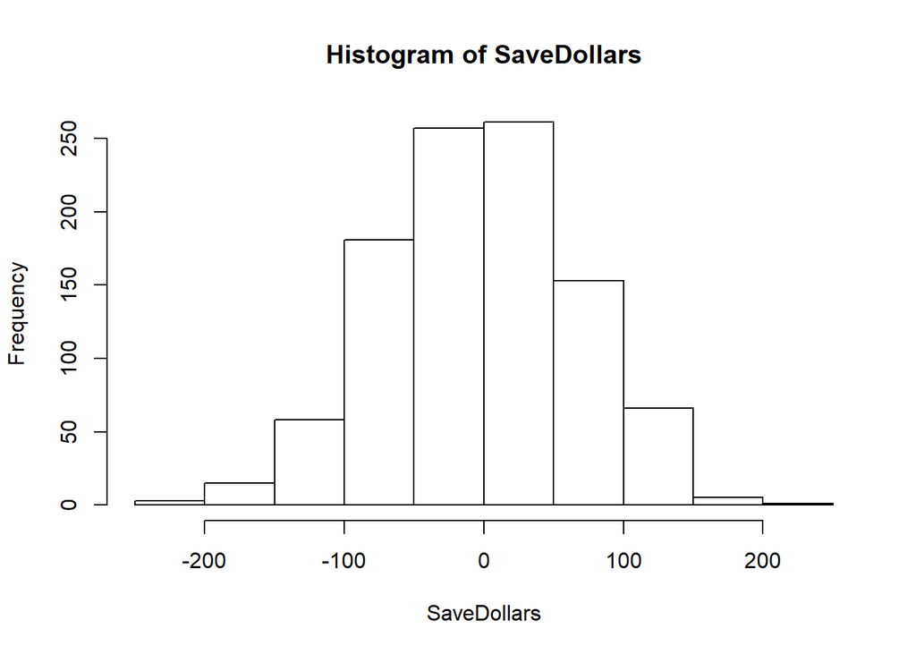

```r
for (loop in 1:1000) {

  TotalDollars = 0
  classsize = 35
  for (i in 1:1137) {
    Bsamples = sample(Bdays,35, replace = TRUE)
    if (length(unique(Bsamples)) == 35) {
      TotalDollars = TotalDollars -4.4
    } else{
      TotalDollars = TotalDollars +1
    }
  }

  SaveDollars[loop] = TotalDollars
}

hist(SaveDollars)
```

```r
var(SaveDollars)
```

```
## [1] 4771.349
```

```r
print(paste("average return =",mean(SaveDollars)))
```

```
## [1] "average return = -3.80940000000009"
```

In the testing we tested the money that Brownlow bet which was 2 dollars to every 1 doolar. We tested between 5 and 10 dollars and the value was too high so we lowered it down to 4 dollars and .40 cents. With this Brownlow has around a zero profit.

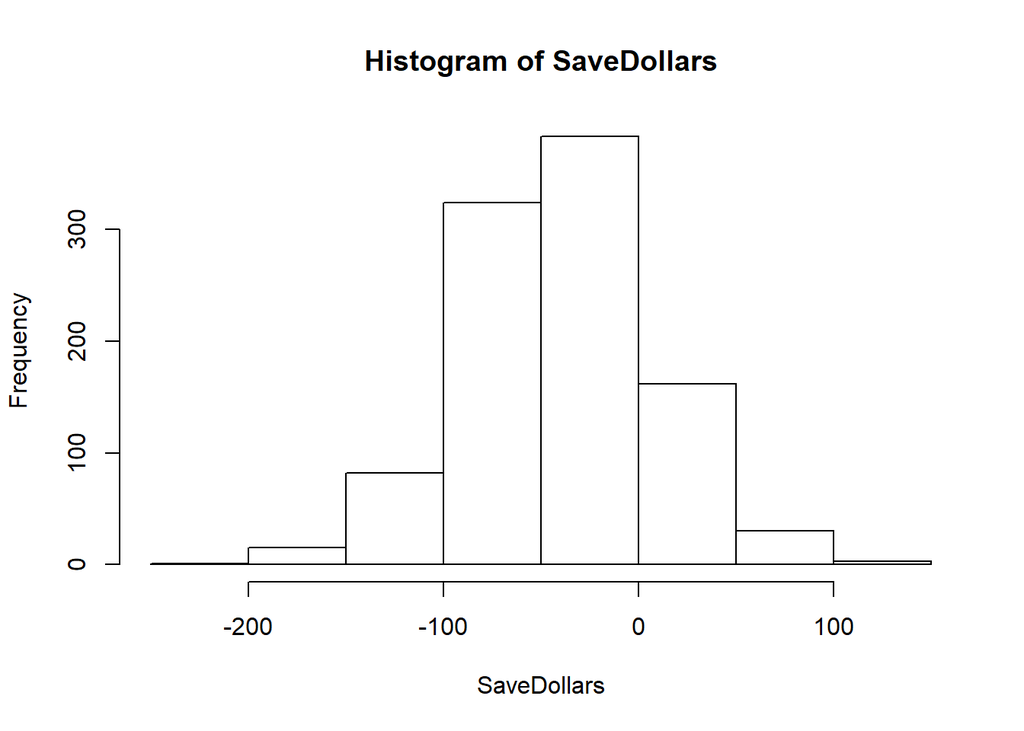

```r
for (loop in 1:1000) {

  TotalDollars = 0
  classsize = 28
  for (i in 1:1137) {
    Bsamples = sample(Bdays,28, replace = TRUE)
    if (length(unique(Bsamples)) == 28) {
      TotalDollars = TotalDollars -2
    } else{
      TotalDollars = TotalDollars +1
    }
  }

  SaveDollars[loop] = TotalDollars
}

hist(SaveDollars)
```

```r
var(SaveDollars)
```

```
## [1] 2354.447
```

```r
print(paste("average return =",mean(SaveDollars)))
```

```
## [1] "average return = -39.882"
```

With this testing we had to change the amount of students from 50 to 40 to 30 to 28 in order to get near the 0 profit.